# Final Project

```r
library(tidyverse)
library(dplyr)
library(scales)
library(hexbin)
```

# Q1

#### Data Loading

```r
data <- read_csv("/Users/Jason/Documents/STOR 320/Data/spotify songAttributes.csv")
```

#### Data Manipulation

```r
names(data) <- c("X", "Acousticness","Danceability","Duration","Energy","Instrumentalness","Key",
                       "Liveness","Loudness","Mode", "Speechiness", "Tempo","Time_Signature", "Valence",
                       "Target","Song_Title","Artist")
data$Duration <- (data$Duration/1000)/60
```

#### Artist to Danceability Plot

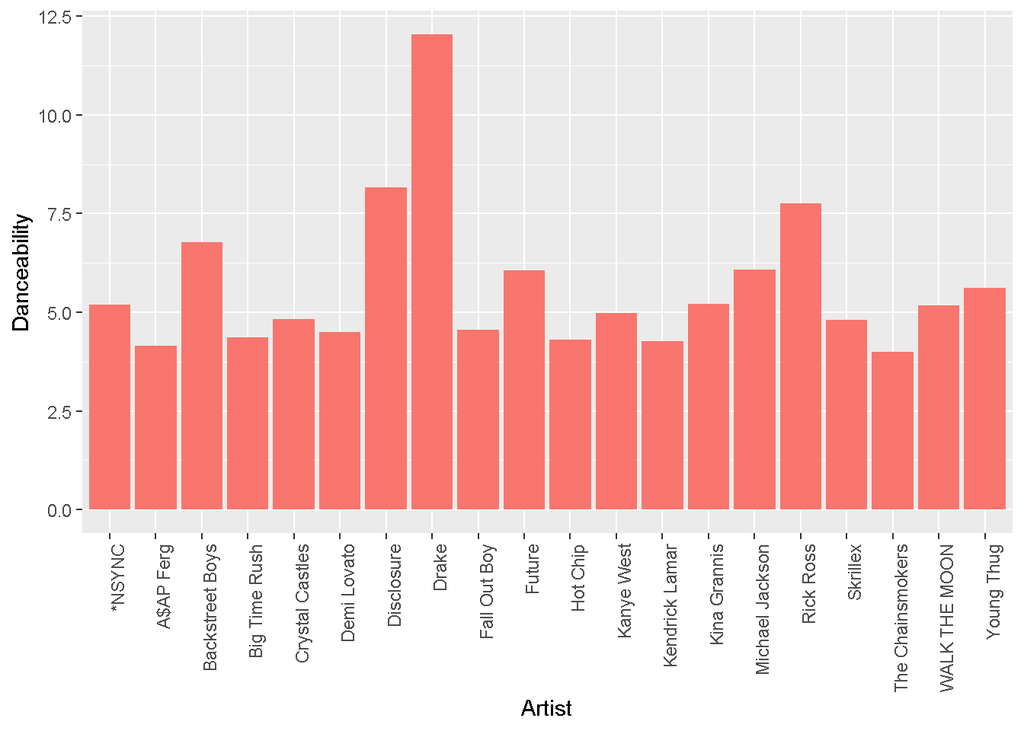

```r
DanceabilityPlot <- group_by(data, Artist)%>% summarize(mostDanced = sum(Danceability)) %>% arrange(desc(mostDanced)) %>% slice(1:20) %>%
  ggplot(aes(x = Artist, y = mostDanced, fill="blue")) + geom_bar(stat="identity") + theme(axis.text.x = element_text(angle = 90, hjust = 1))+ theme(legend.position="none") + ylab("Danceability") + xlab("Artist")

DanceabilityPlot
```

#### Artist to Energy Plot

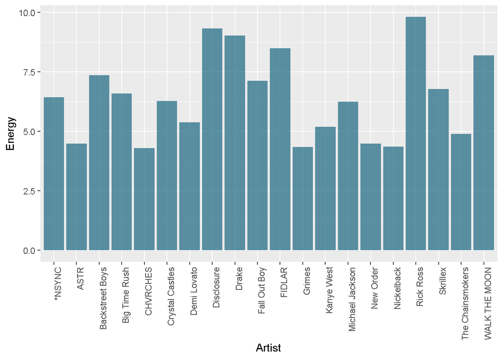

```r
EnergyPlot <- group_by(data, Artist)  %>% summarize(mostEnergetic = sum(Energy)) %>% arrange(desc(mostEnergetic)) %>% slice(1:20) %>%
  ggplot(aes(x = Artist, y = mostEnergetic)) + geom_bar(stat="identity", fill=rgb(0.1,0.4,0.5,0.7)) + theme(axis.text.x = element_text(angle = 90, hjust = 1)) + ylab("Energy") + xlab("Artist")

EnergyPlot
```

#### Artist to Instrumental Plot

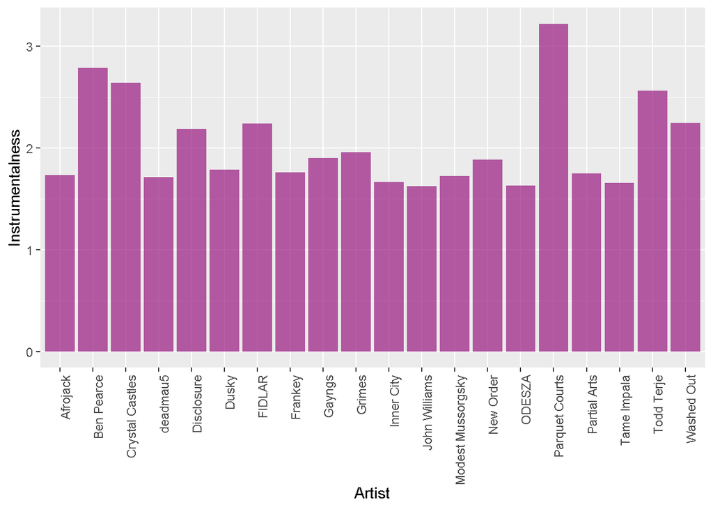

```r
InstrumentalPlot <- group_by(data, Artist)  %>% summarize(mostInstrumental = sum(Instrumentalness)) %>% arrange(desc(mostInstrumental)) %>% slice(1:20) %>%
  ggplot(aes(x = Artist, y = mostInstrumental)) + geom_bar(stat="identity", fill=rgb(0.6,0.1,0.5,0.7)) + theme(axis.text.x = element_text(angle = 90, hjust = 1)) + ylab("Instrumentalness") + xlab("Artist")

InstrumentalPlot
```

#### Artist to Live Plot

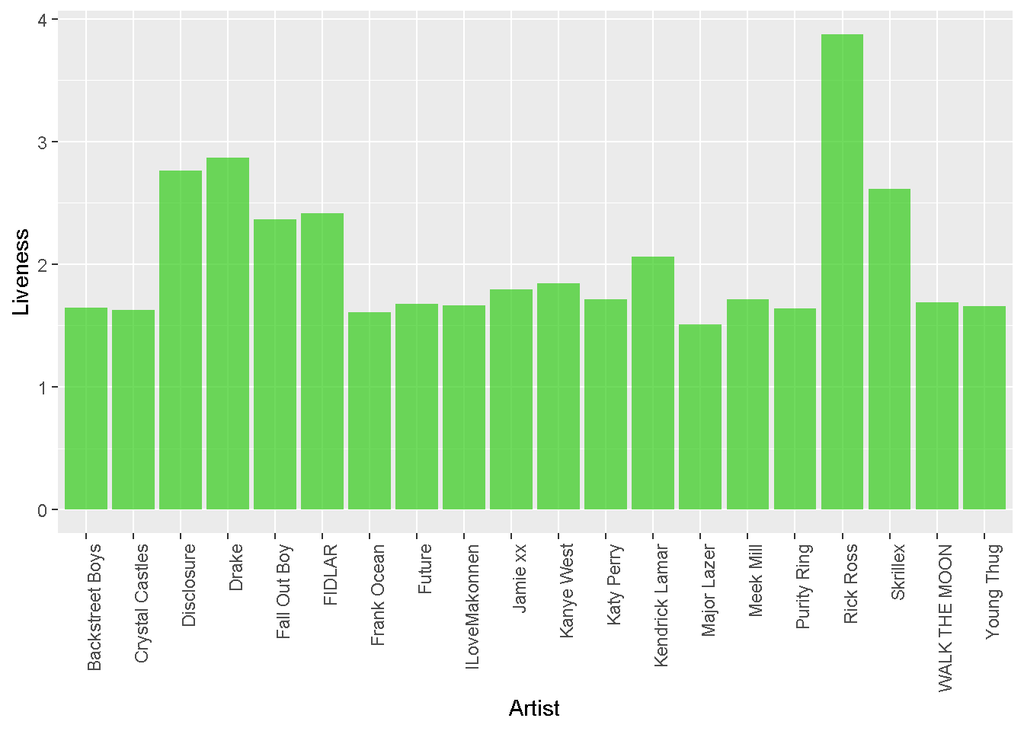

```r
LivePlot <-group_by(data, Artist)  %>% summarize(mostLively = sum(Liveness)) %>% arrange(desc(mostLively)) %>% slice(1:20) %>%
  ggplot(aes(x = Artist, y = mostLively)) + geom_bar(stat="identity", fill=rgb(0.2,0.8,0.1,0.7)) + theme(axis.text.x = element_text(angle = 90, hjust = 1)) + ylab("Liveness") + xlab("Artist")

LivePlot
```

#### Artist to Valence Plot

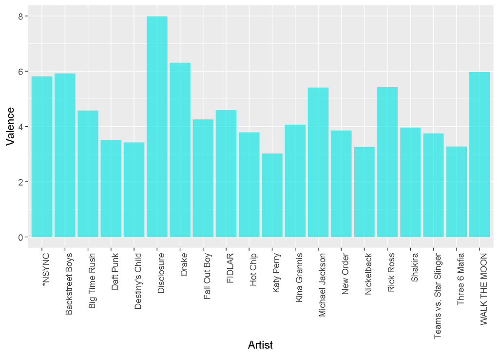

```r
ValencePlot <-group_by(data, Artist)  %>% summarize(Valence = sum(Valence)) %>% arrange(desc(Valence)) %>% slice(1:20) %>%
  ggplot(aes(x = Artist, y = Valence)) + geom_bar(stat="identity",fill=rgb(0.1,0.9,0.9,0.7)) + theme(axis.text.x = element_text(angle = 90, hjust = 1))

ValencePlot
```

#### Valence to Danceability Plot

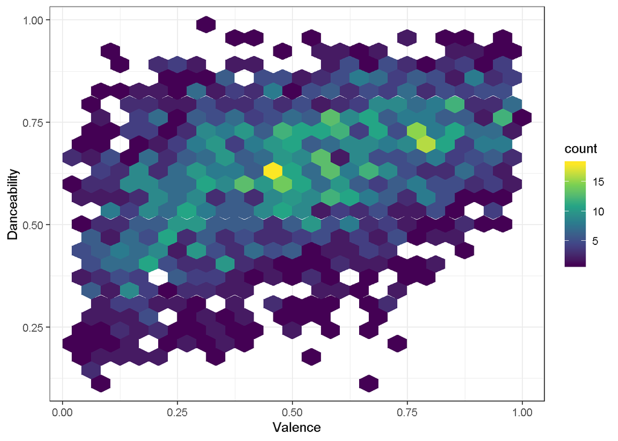

```r
ggplot(data, aes(x = Valence, y = Danceability)) +
   geom_hex(bins = 23) +
  scale_fill_continuous(type = "viridis") +
  theme_bw()
```

#### Valence to Speechiness plot

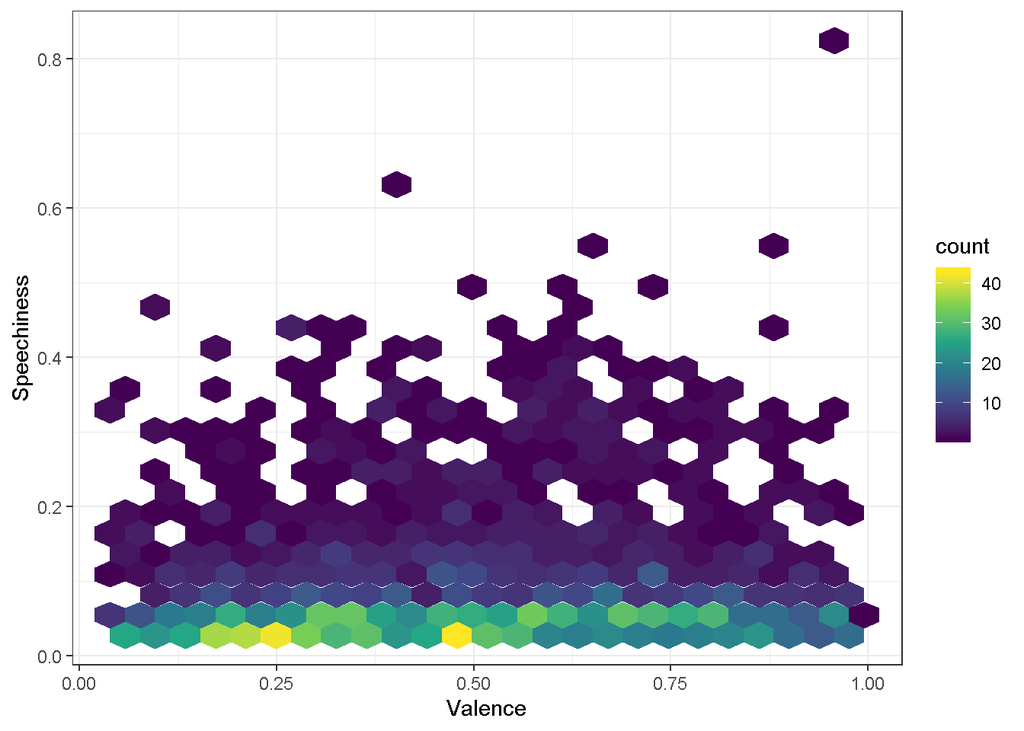

```r
ggplot(data, aes(x = Valence, y = Speechiness)) +
   geom_hex(bins = 25) +
  scale_fill_continuous(type = "viridis") +
  theme_bw()
```

# Q2/Q4

#### Data Loading

```r
worldwide <- read_csv("/Users/Jason/Documents/STOR 320/Data/worldwide-spotify.csv")
top50Country <- read_csv("/Users/Jason/Documents/STOR 320/Data/top50country.csv")
songAttributes <- read_csv("/Users/Jason/Documents/STOR 320/Data/spotify songAttributes.csv")
```

#### Data Manipulation

```r
worldwide2 <- select(worldwide, -Position , Song = 'Track Name')
worldwide2 <- mutate(worldwide2, Song = tolower(Song))


songAttributes2 <- mutate(songAttributes, song_title = tolower(song_title))


newdata <- inner_join(songAttributes2, worldwide2, by = c("song_title" = "Song"))


sums <- group_by(newdata, song_title) %>% summarize(Streams = sum(Streams))



newdata2 <- newdata[!duplicated(newdata$song_title), ]

newdata2 <- select(newdata2, -X1, -Streams, -Date)


songs <- inner_join(newdata2, sums, by = "song_title")

songs_standard = mutate(songs, "pop" = rescale(songs$Streams, to = c(50, 100)), dnce = songs$danceability*100, acous = rescale(songs$acousticness, to = c(1, 100)), nrgy = energy*100, dB = loudness, dur = songs$duration_ms/1000, title=songs$song_title, artist=artist)

top50_2015 = filter(top50Country, year >= 2015)
```

#### Simple Linear Regression

```r
attach(top50_2015)
lm.fit1 = lm(pop ~ dnce)
```

```r
summary(lm.fit1)
```

```
##
## Call:
## lm(formula = pop ~ dnce)
##
## Residuals:
##     Min      1Q  Median      3Q     Max
## -46.236  -6.889   2.198   9.196  20.501
##
## Coefficients:
##             Estimate Std. Error t value Pr(>|t|)
## (Intercept) 65.41435    2.68311  24.380  < 2e-16 ***
## dnce         0.21734    0.03807   5.709 1.71e-08 ***
## ---
## Signif. codes:  0 '***' 0.001 '**' 0.01 '*' 0.05 '.' 0.1 ' ' 1
##
## Residual standard error: 13.36 on 669 degrees of freedom
##   (1 observation deleted due to missingness)
## Multiple R-squared:  0.04646,    Adjusted R-squared:  0.04503
## F-statistic:  32.6 on 1 and 669 DF,  p-value: 1.707e-08
```

From the gression we can see, the r^2 is very low although the p-value for the dancebility is almost zero. Thus, we should introduce more predictors into the regression and then we try multiple linear regression. We gradually put in more predictors to see how models change.

#### Multiple Linear Regression

```r
lm.fit2 = lm(pop ~ dnce+acous+dur)
```

```r
summary(lm.fit2)
```

```
##
## Call:
## lm(formula = pop ~ dnce + acous + dur)
##
## Residuals:
##     Min      1Q  Median      3Q     Max
## -39.278  -7.888   1.101  10.059  19.583
##
## Coefficients:
##              Estimate Std. Error t value Pr(>|t|)
## (Intercept) 81.533187   3.705038  22.006  < 2e-16 ***
## dnce         0.195872   0.037747   5.189 2.81e-07 ***
## acous        0.002335   0.020684   0.113     0.91
## dur         -0.069129   0.010147  -6.813 2.14e-11 ***
## ---
## Signif. codes:  0 '***' 0.001 '**' 0.01 '*' 0.05 '.' 0.1 ' ' 1
##
## Residual standard error: 12.94 on 667 degrees of freedom
##   (1 observation deleted due to missingness)
## Multiple R-squared:  0.1086, Adjusted R-squared:  0.1046
## F-statistic: 27.08 on 3 and 667 DF,  p-value: < 2.2e-16
```

From the model, we can see that duration and danceability are statitically significant at any significance level, but acousticness is not.

```r
lm.fit3 = lm(pop ~ dnce+acous+dur+bpm+nrgy+dB+live+val)
```

```r
summary(lm.fit3)
```

```
##
## Call:
## lm(formula = pop ~ dnce + acous + dur + bpm + nrgy + dB + live +
##     val)
##
## Residuals:
##     Min      1Q  Median      3Q     Max
## -42.474  -7.563   2.256   8.288  21.213
##
## Coefficients:
##              Estimate Std. Error t value Pr(>|t|)
## (Intercept) 108.05502    6.28714  17.187  < 2e-16 ***
## dnce          0.20658    0.04164   4.961 8.91e-07 ***
## acous        -0.04555    0.02339  -1.947   0.0519 .
## dur          -0.06623    0.01003  -6.602 8.34e-11 ***
## bpm           0.01987    0.01667   1.192   0.2336
## nrgy         -0.28479    0.05228  -5.447 7.23e-08 ***
## dB            1.45522    0.29489   4.935 1.02e-06 ***
## live         -0.02251    0.02850  -0.790   0.4299
## val          -0.02573    0.03002  -0.857   0.3918
## ---
## Signif. codes:  0 '***' 0.001 '**' 0.01 '*' 0.05 '.' 0.1 ' ' 1
##
## Residual standard error: 12.6 on 662 degrees of freedom
##   (1 observation deleted due to missingness)
## Multiple R-squared:  0.1609, Adjusted R-squared:  0.1507
## F-statistic: 15.86 on 8 and 662 DF,  p-value: < 2.2e-16
```

From the linear regression we can find bpm, live, val are not statistically important at all significance level, so we just remove these values in the following tried model.

```r
lm.fit4 = lm(pop ~ dnce+acous+dur+nrgy+dB)
summary(lm.fit4)
```

```
##
## Call:
## lm(formula = pop ~ dnce + acous + dur + nrgy + dB)
##
## Residuals:
##     Min      1Q  Median      3Q     Max
## -42.995  -7.226   1.784   9.181  21.669
##
## Coefficients:
##               Estimate Std. Error t value Pr(>|t|)
## (Intercept) 110.351442   5.892877  18.726  < 2e-16 ***
## dnce          0.190043   0.036789   5.166 3.17e-07 ***
## acous        -0.049235   0.023254  -2.117   0.0346 *
## dur          -0.064745   0.009919  -6.528 1.33e-10 ***
## nrgy         -0.299198   0.048809  -6.130 1.51e-09 ***
## dB            1.439182   0.292708   4.917 1.11e-06 ***
## ---
## Signif. codes:  0 '***' 0.001 '**' 0.01 '*' 0.05 '.' 0.1 ' ' 1
##
## Residual standard error: 12.6 on 665 degrees of freedom
##   (1 observation deleted due to missingness)
## Multiple R-squared:  0.1572, Adjusted R-squared:  0.1509
## F-statistic: 24.82 on 5 and 665 DF,  p-value: < 2.2e-16
```

Although the r^2 increases compared to the simple linear regression, it is still rather low. From the summary, we can see that danceability, duration, energy, and dB are statistically important.

#### Data Plots

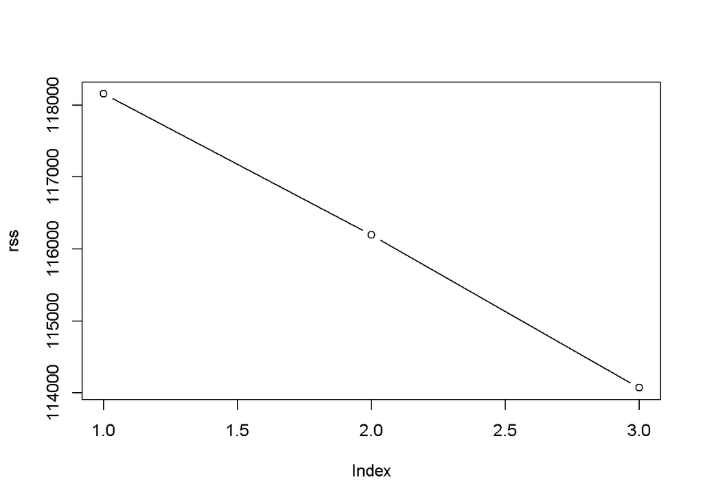

```r
#
#data.frame(top50_2015)
#$adj.r.squared
top50_2015<-na.omit(top50_2015)
rss <- rep(0,3)
for(d in 1:3){
poly.fit1=glm(pop~poly(dnce,d), data=top50_2015)
rss[d] <- sum(poly.fit1$residuals^2)
#print(summary(poly.fit1))
#print(summary(poly.fit1)$adj.r.squared)
#pred=predict(fit, data.frame(dis=seq(min(Boston$dis),max(Boston$dis),length.out = 100)))
#lines(seq(min(Boston$dis),max(Boston$dis),length.out = 100),pred,col=d)
}
plot(rss, type="b")
```

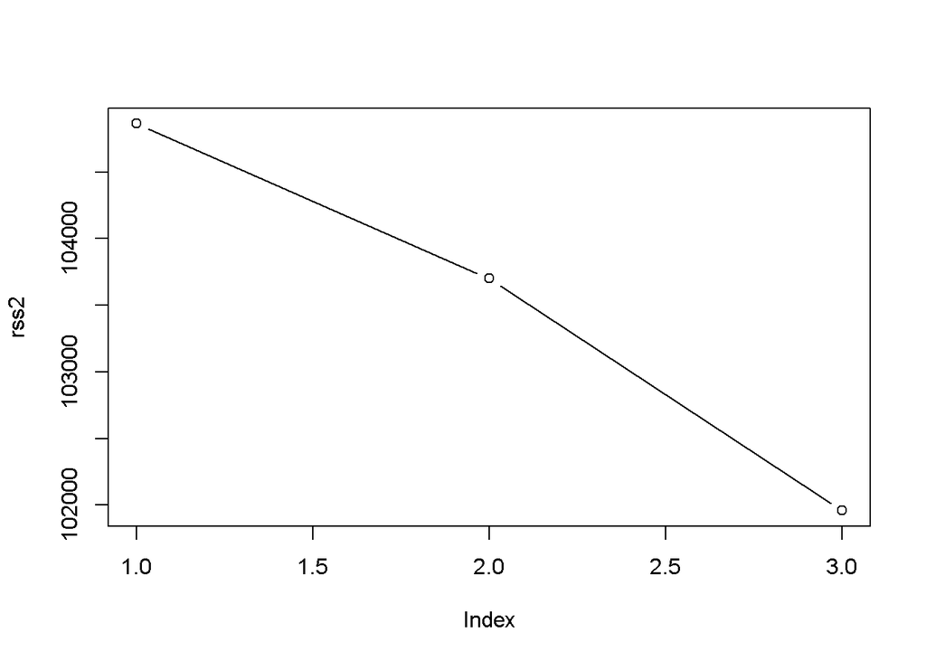

```r
rss2 <- rep()
for(d in 1:3){
poly.fit2=glm(pop~poly(dnce,d)+dur+acous+nrgy+dB, data=top50_2015)
rss2[d] <- sum(poly.fit2$residuals^2)
#print(summary(poly.fit1))
#print(summary(poly.fit1)$adj.r.squared)
#pred=predict(fit, data.frame(dis=seq(min(Boston$dis),max(Boston$dis),length.out = 100)))
#lines(seq(min(Boston$dis),max(Boston$dis),length.out = 100),pred,col=d)
}
plot(rss2, type="b")
```

#### Data Exploratory Analysis

To find how popularity can be predicted, I first use the top50 songs in different countries.During the attempt of deciding which variables are statistically important, I use linear regression. At first, R^2 is rather low and I remove some variables that are not related to popularity. From the results above we can see, the highest R^2 is only 0.15 and when we tried different polynomial dimensions for danceability, the rss is also very high.

Thus, I add the data frame which does not show popularity directly, but I standardize all these variables like dB(loudness), duration(in second unit), energy. Now I combine these two data frames and try some models.

#### Data Manipulation Part 2

```r
songs_pop_com = bind_rows(select(top50_2015, "title", "artist", "dnce", "acous", "dur", "nrgy", "dB", "pop"), select(songs_standard, "title", "artist", "dnce", "acous", "dur", "nrgy", "dB", "pop"))


set.seed(42)
rows = sample(nrow(songs_pop_com))
songs_pop_com = songs_pop_com[rows,]
```

#### Multiple Linear Regression

```r
attach(songs_pop_com)
lm.fit4 = lm(pop ~ dnce+acous+dur+nrgy+dB)
summary(lm.fit4)
```

```
##
## Call:
## lm(formula = pop ~ dnce + acous + dur + nrgy + dB)
##
## Residuals:
##     Min      1Q  Median      3Q     Max
## -37.065 -14.197  -1.792  14.086  33.585
##
## Coefficients:
##              Estimate Std. Error t value Pr(>|t|)
## (Intercept) 99.120745   5.670283  17.481  < 2e-16 ***
## dnce         0.256945   0.035428   7.253 7.52e-13 ***
## acous        0.090875   0.023953   3.794 0.000156 ***
## dur         -0.068170   0.009424  -7.233 8.62e-13 ***
## nrgy        -0.327314   0.045939  -7.125 1.84e-12 ***
## dB           2.253961   0.278120   8.104 1.36e-15 ***
## ---
## Signif. codes:  0 '***' 0.001 '**' 0.01 '*' 0.05 '.' 0.1 ' ' 1
##
## Residual standard error: 16.21 on 1141 degrees of freedom
## Multiple R-squared:  0.1831, Adjusted R-squared:  0.1795
## F-statistic: 51.15 on 5 and 1141 DF,  p-value: < 2.2e-16
```

After trying the multiple linear regression, we can see R^2 increases a little, but is still quite low.

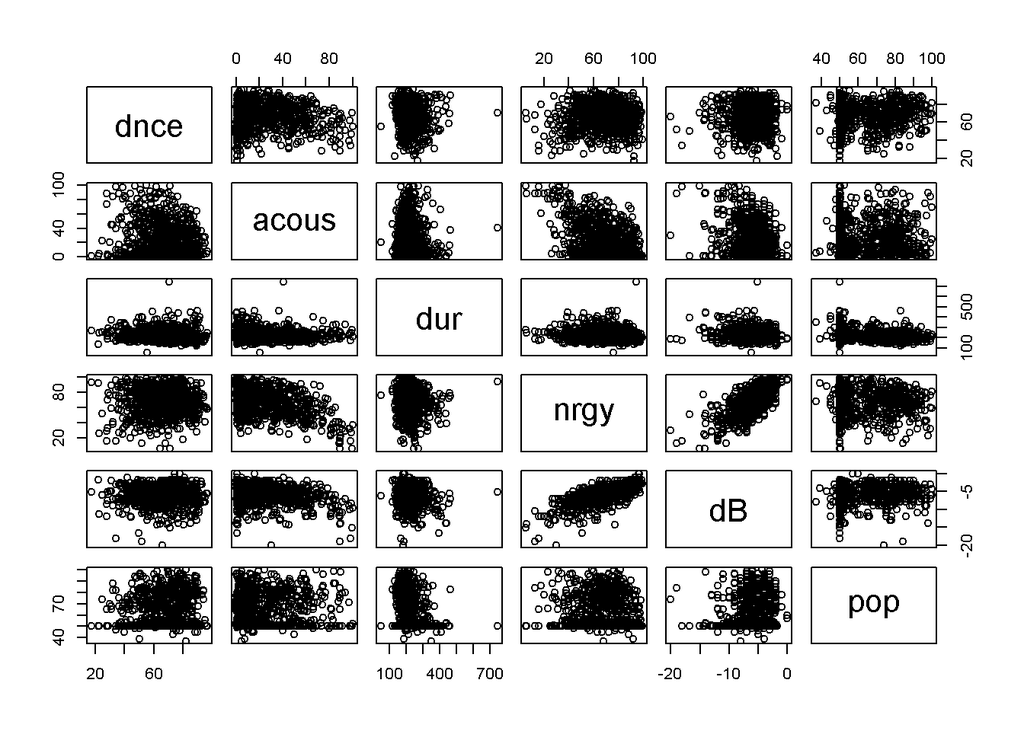

```r
pairs(select(songs_pop_com, -title, -artist))
```

To see the relationship between each two variables, we draw the scatterplots. From the picture we can see that there are not obvious linear relationship between popularity and any other variables. However, there are linear relationship among predictors such that energy and dB, which can cause collinearity.

Since we do not see obvious linear relationship between any independent variable and popularity, we guess there are may be some polynomial relationship between independent variables and popularity. Thus, we tried several polynomial regression to see whether we can make the prediction better. We use residual sum of squares to see the prediction to see whether rss decreases in that model and if so, we go further to put the regression onto the test dataset. We judge the prediction level by Mean-squared error.

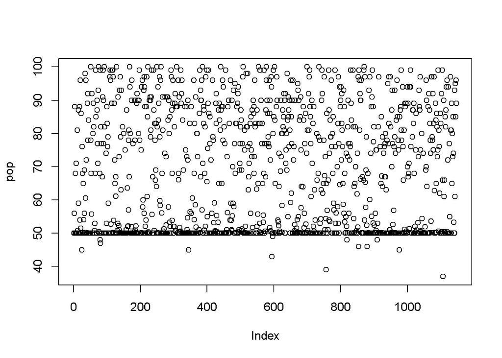

```r
plot(pop)
```

#### Polynomial Regression

```r
songs_pop_com<-na.omit(songs_pop_com)
```

```r
train <-1:1000
songs.train <- songs_pop_com[train,]
songs.test <- songs_pop_com[-train,]
```

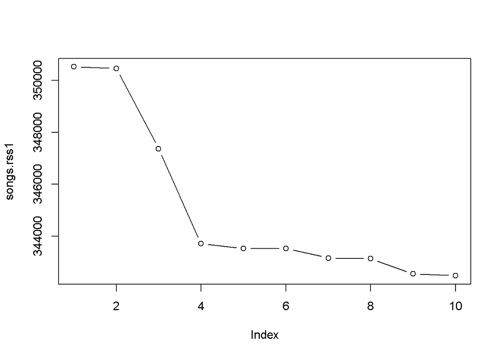

```r
songs.rss1 <- rep(0,3)
for(d in 1:10){
poly.fit1=glm(pop~poly(dnce,d), data=songs_pop_com)
songs.rss1[d] <- sum(poly.fit1$residuals^2)

}
plot(songs.rss1, type="b")
```

When I tried only the danceability, the rss is still quite high after I choose a high dimension polynomial regression (up to 10).

```r
summary(poly.fit1)
```

```
##
## Call:
## glm(formula = pop ~ poly(dnce, d), data = songs_pop_com)
##
## Deviance Residuals:
##     Min       1Q   Median       3Q      Max
## -37.765  -14.623   -1.867   15.563   34.401
##
## Coefficients:
##                 Estimate Std. Error t value Pr(>|t|)
## (Intercept)      68.3835     0.5127 133.384  < 2e-16 ***
## poly(dnce, d)1  128.9061    17.3633   7.424 2.22e-13 ***
## poly(dnce, d)2   -7.8112    17.3633  -0.450 0.652891
## poly(dnce, d)3  -55.5715    17.3633  -3.201 0.001410 **
## poly(dnce, d)4  -60.4640    17.3633  -3.482 0.000516 ***
## poly(dnce, d)5  -13.4571    17.3633  -0.775 0.438481
## poly(dnce, d)6   -0.8580    17.3633  -0.049 0.960600
## poly(dnce, d)7   19.1995    17.3633   1.106 0.269067
## poly(dnce, d)8    4.8219    17.3633   0.278 0.781288
## poly(dnce, d)9  -24.1520    17.3633  -1.391 0.164502
## poly(dnce, d)10   8.5086    17.3633   0.490 0.624202
## ---
## Signif. codes:  0 '***' 0.001 '**' 0.01 '*' 0.05 '.' 0.1 ' ' 1
##
## (Dispersion parameter for gaussian family taken to be 301.4827)
##
##     Null deviance: 367136  on 1146  degrees of freedom
## Residual deviance: 342484  on 1136  degrees of freedom
## AIC: 9815.9
##
## Number of Fisher Scoring iterations: 2
```

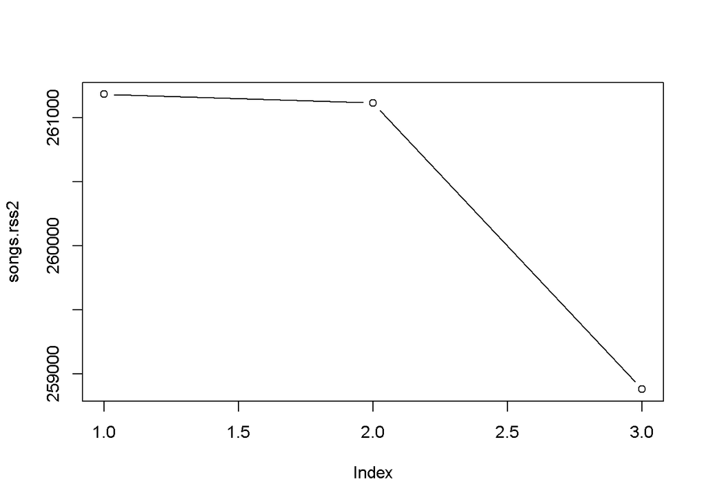

```r
songs.rss2 <- rep(0, 3)
for(d in 1:3){
poly.fit2=glm(pop~poly(dnce,d)+dur+acous+nrgy+dB, data=songs.train)
songs.rss2[d] <- sum(poly.fit2$residuals^2)

}
plot(songs.rss2, type="b")
```

```r
summary(poly.fit2)
```

```
##
## Call:
## glm(formula = pop ~ poly(dnce, d) + dur + acous + nrgy + dB,
##     data = songs.train)
##
## Deviance Residuals:
##     Min       1Q   Median       3Q      Max
## -34.220  -14.445   -1.504   13.047   34.671
##
## Coefficients:
##                 Estimate Std. Error t value Pr(>|t|)
## (Intercept)    119.78961    5.30472  22.582  < 2e-16 ***
## poly(dnce, d)1 105.81520   16.34337   6.475 1.49e-10 ***
## poly(dnce, d)2  -8.34694   16.23251  -0.514  0.60722
## poly(dnce, d)3 -47.32063   16.16843  -2.927  0.00350 **
## dur             -0.07263    0.01037  -7.006 4.53e-12 ***
## acous            0.07084    0.02553   2.774  0.00563 **
## nrgy            -0.35087    0.04904  -7.155 1.62e-12 ***
## dB               2.33628    0.29593   7.895 7.68e-15 ***
## ---
## Signif. codes:  0 '***' 0.001 '**' 0.01 '*' 0.05 '.' 0.1 ' ' 1
##
## (Dispersion parameter for gaussian family taken to be 260.9697)
##
##     Null deviance: 320592  on 999  degrees of freedom
## Residual deviance: 258882  on 992  degrees of freedom
## AIC: 8412.2
##
## Number of Fisher Scoring iterations: 2
```

From the summary we can see that after add all the predictors, the poly degree=1 and 3 for danceability, the duration, acousticness, energy, and dB are all statistically important.

```r
poly.pred2 = predict(poly.fit2, newdata = songs.test, se = TRUE)
summary((poly.pred2['fit']-songs.test[, 'pop'])^2)
```

```
##       pop
##  Min.   :   0.573
##  1st Qu.:  70.913
##  Median : 183.811
##  Mean   : 263.547
##  3rd Qu.: 384.884
##  Max.   :1054.769
```

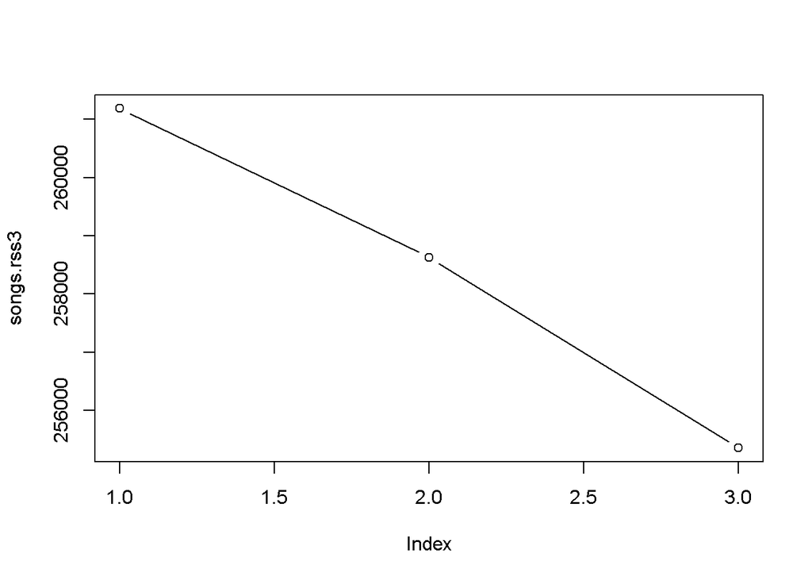

```r
songs.rss3 <- rep(0, 3)
for(d in 1:3){
poly.fit3=glm(pop~poly(dnce,d)+poly(dur, d)+acous+nrgy+dB, data=songs.train)
songs.rss3[d] <- sum(poly.fit3$residuals^2)

}
plot(songs.rss3, type="b")
```

```r
summary(poly.fit3)
```

```
##
## Call:
## glm(formula = pop ~ poly(dnce, d) + poly(dur, d) + acous + nrgy +
##     dB, data = songs.train)
##
## Deviance Residuals:
##     Min       1Q   Median       3Q      Max
## -35.488  -14.011   -1.907   12.848   33.876
##
## Coefficients:
##                  Estimate Std. Error t value Pr(>|t|)
## (Intercept)     106.25317    4.94139  21.503  < 2e-16 ***
## poly(dnce, d)1   96.54112   16.44479   5.871 5.92e-09 ***
## poly(dnce, d)2  -13.76111   16.30573  -0.844  0.39891
## poly(dnce, d)3  -52.08268   16.12788  -3.229  0.00128 **
## poly(dur, d)1  -113.86415   16.36858  -6.956 6.34e-12 ***
## poly(dur, d)2    55.87304   16.68117   3.349  0.00084 ***
## poly(dur, d)3    25.27123   16.14993   1.565  0.11795
## acous             0.07197    0.02546   2.826  0.00480 **
## nrgy             -0.37001    0.04903  -7.547 1.01e-13 ***
## dB                2.52659    0.29905   8.449  < 2e-16 ***
## ---
## Signif. codes:  0 '***' 0.001 '**' 0.01 '*' 0.05 '.' 0.1 ' ' 1
##
## (Dispersion parameter for gaussian family taken to be 257.934)
##
##     Null deviance: 320592  on 999  degrees of freedom
## Residual deviance: 255355  on 990  degrees of freedom
## AIC: 8402.5
##
## Number of Fisher Scoring iterations: 2
```

```r
poly.pred3 = predict(poly.fit3, newdata = songs.test, se = TRUE)
summary((poly.pred3['fit']-songs.test[, 'pop'])^2)
```

```
##       pop
##  Min.   :    0.02
##  1st Qu.:   59.77
##  Median :  177.38
##  Mean   :  599.26
##  3rd Qu.:  382.10
##  Max.   :49641.23
```

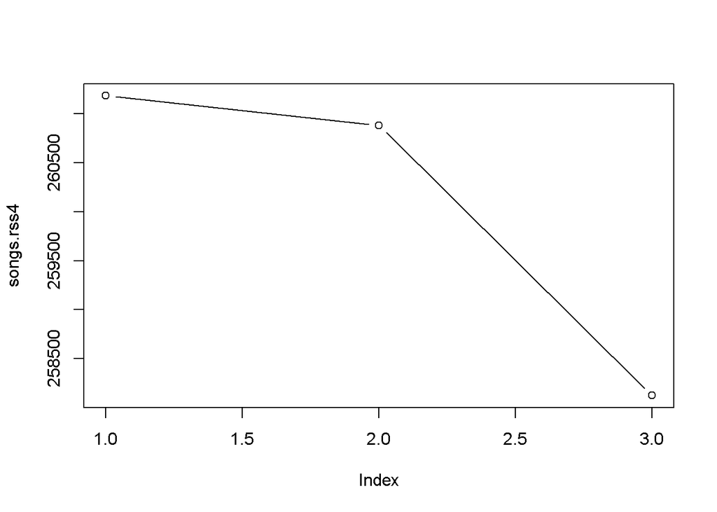

```r
songs.rss4 <- rep(0, 3)
for(d in 1:3){
poly.fit4=glm(pop~poly(dnce,d)+dur+poly(acous, d)+nrgy+dB, data=songs.train)
songs.rss4[d] <- sum(poly.fit4$residuals^2)

}
plot(songs.rss4, type="b")
```

```r
summary(poly.fit4)
```

```
##
## Call:
## glm(formula = pop ~ poly(dnce, d) + dur + poly(acous, d) + nrgy +
##     dB, data = songs.train)
##
## Deviance Residuals:
##     Min       1Q   Median       3Q      Max
## -34.285  -14.257   -1.691   12.918   35.198
##
## Coefficients:
##                  Estimate Std. Error t value Pr(>|t|)
## (Intercept)     121.18580    5.06497  23.926  < 2e-16 ***
## poly(dnce, d)1  110.32272   16.65308   6.625 5.70e-11 ***
## poly(dnce, d)2   -9.16179   16.23211  -0.564  0.57259
## poly(dnce, d)3  -48.24367   16.18941  -2.980  0.00295 **
## dur              -0.07265    0.01037  -7.003 4.63e-12 ***
## poly(acous, d)1  54.52895   19.39862   2.811  0.00504 **
## poly(acous, d)2  14.55622   16.98454   0.857  0.39164
## poly(acous, d)3 -23.87249   16.32233  -1.463  0.14390
## nrgy             -0.34722    0.04970  -6.986 5.20e-12 ***
## dB                2.32882    0.29629   7.860 1.00e-14 ***
## ---
## Signif. codes:  0 '***' 0.001 '**' 0.01 '*' 0.05 '.' 0.1 ' ' 1
##
## (Dispersion parameter for gaussian family taken to be 260.7303)
##
##     Null deviance: 320592  on 999  degrees of freedom
## Residual deviance: 258123  on 990  degrees of freedom
## AIC: 8413.3
##
## Number of Fisher Scoring iterations: 2
```

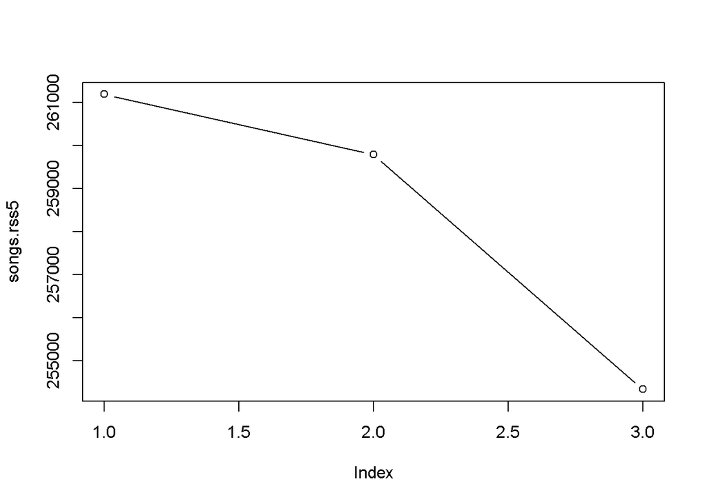

```r
songs.rss5 <- rep(0, 3)
for(d in 1:3){
poly.fit5=glm(pop~poly(dnce,d)+dur+acous+poly(nrgy, d)+dB, data=songs.train)
songs.rss5[d] <- sum(poly.fit5$residuals^2)

}
plot(songs.rss5, type="b")
```

```r
summary(poly.fit5)
```

```
##
## Call:
## glm(formula = pop ~ poly(dnce, d) + dur + acous + poly(nrgy,
##     d) + dB, data = songs.train)
##
## Deviance Residuals:
##     Min       1Q   Median       3Q      Max
## -32.899  -14.237   -1.157   13.456   33.976
##
## Coefficients:
##                  Estimate Std. Error t value Pr(>|t|)
## (Intercept)      96.26789    2.87175  33.522  < 2e-16 ***
## poly(dnce, d)1   94.18727   16.55670   5.689 1.68e-08 ***
## poly(dnce, d)2   -6.32843   16.13861  -0.392 0.695047
## poly(dnce, d)3  -49.38442   16.15205  -3.057 0.002292 **
## dur              -0.07563    0.01031  -7.333 4.66e-13 ***
## acous             0.08157    0.02624   3.109 0.001933 **
## poly(nrgy, d)1 -177.82198   26.15178  -6.800 1.81e-11 ***
## poly(nrgy, d)2  -43.62664   17.25256  -2.529 0.011603 *
## poly(nrgy, d)3  -53.53964   16.21579  -3.302 0.000995 ***
## dB                2.30883    0.29909   7.720 2.85e-14 ***
## ---
## Signif. codes:  0 '***' 0.001 '**' 0.01 '*' 0.05 '.' 0.1 ' ' 1
##
## (Dispersion parameter for gaussian family taken to be 256.9077)
##
##     Null deviance: 320592  on 999  degrees of freedom
## Residual deviance: 254339  on 990  degrees of freedom
## AIC: 8398.5
##
## Number of Fisher Scoring iterations: 2
```

```r
poly.pred5 = predict(poly.fit5, newdata = songs.test, se = TRUE)
summary((poly.pred5['fit']-songs.test[, 'pop'])^2)
```

```
##       pop
##  Min.   :   0.021
##  1st Qu.:  63.685
##  Median : 211.042
##  Mean   : 261.577
##  3rd Qu.: 390.212
##  Max.   :1000.251
```

Since there are a lot of predictors in this model, once two or more predictors are highly correlated, linear regression will perform not very well. Our prediction results will have a high variance instead. Thus, we need to use some prediction models that can penalize unimportant predictors and predict better when there are many attributes. We tried lasso first.

#### Lasso Regression

```r
library(glmnet)
lasso.cv<- cv.glmnet(as.matrix(select(songs.train, -title, - artist)), as.matrix(songs_pop_com[train,'pop']), alpha = 1)
lasso.lambda <- lasso.cv$lambda.min
lasso.lambda
```

```
## [1] 0.5728316
```

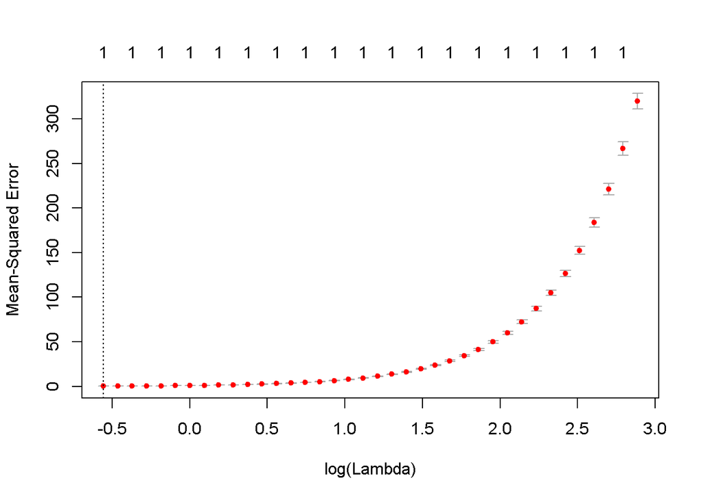

```r
plot(lasso.cv)
```

```r
x = model.matrix(pop ~.-title - artist, data=songs.train)
x.test = model.matrix(pop ~. -title -artist, data=songs.test)
y = songs.train$pop

songs.glm = glmnet(x,y, lambda = lasso.lambda)
songs.pred = predict(songs.glm, x.test)

summary((songs.pred[, 's0']-songs.test[, 'pop'])^2)
```

```
##       pop
##  Min.   :   0.2361
##  1st Qu.:  94.7360
##  Median : 205.0385
##  Mean   : 266.1223
##  3rd Qu.: 396.4054
##  Max.   :1043.2312
```

Besides linear regression, I tried lasso regression which works well in the dataset that has a lot of predictors and some of them may not very important or has a low weight on the popularity.

To use lasso, I first use cross validation to decide which lambda can achieve the lowest mean squared error in train set. After we gain the optimized lambda (penalized parameter), we can apply it on the test dataset.

Ridge Regression

```r
set.seed(5)
ridge.cv<- cv.glmnet(as.matrix(dplyr::select(songs.train, -title, -artist)), as.matrix(songs_pop_com[train,'pop']), alpha = 0)
ridge.lambda <- ridge.cv$lambda.min
ridge.lambda
```

```
## [1] 1.965081
```

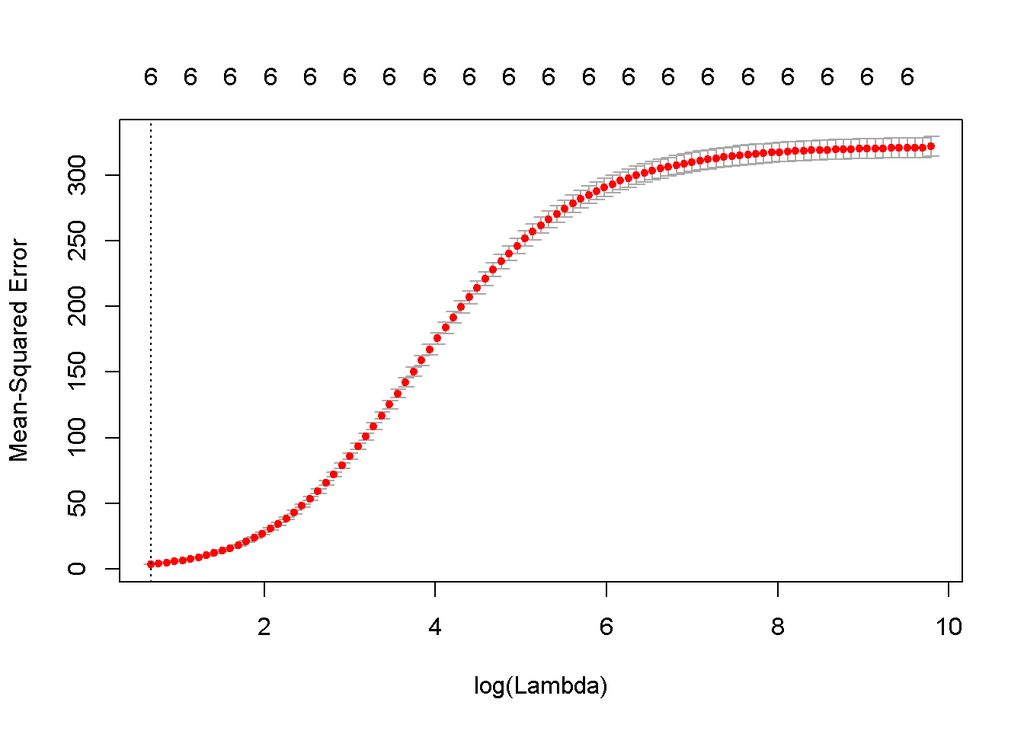

```r
plot(ridge.cv)
```

```r
pred.ridge <- predict(ridge.cv, s=ridge.lambda, newx=x.test)
summary((songs_pop_com[-train,'pop'] - pred.ridge)^2)
```

```
##       pop
##  Min.   : 810.6
##  1st Qu.:1414.6
##  Median :3136.9
##  Mean   :3504.1
##  3rd Qu.:5413.8
##  Max.   :8735.6
```

```r
predict(ridge.cv, s=ridge.lambda, type="coefficients")
```

```
## 7 x 1 sparse Matrix of class "dgCMatrix"
##                        1
## (Intercept) 10.782358580
## dnce         0.026201842
## acous        0.008963647
## dur         -0.007993540
## nrgy        -0.029117663
## dB           0.200371697
## pop          0.884502393
```

By comparing their Mean-squared Error, we can see that ridge regression performs much worse than lasso regression.Since ridge regression cannot put the weights of some predictors to be exactly zero, it cannot better perform when the relationship of predictors and popularity is not clear.

#### Random Forest

```r
library(randomForest)
songs.rf= randomForest(pop~dnce+acous+dur+nrgy+dB, data = songs_pop_com,subset=train, importance= TRUE)
songs.rf
```

```
##
## Call:
##  randomForest(formula = pop ~ dnce + acous + dur + nrgy + dB,      data = songs_pop_com, importance = TRUE, subset = train)
##                Type of random forest: regression
##                      Number of trees: 500
## No. of variables tried at each split: 1
##
##           Mean of squared residuals: 101.4564
##                     % Var explained: 68.35
```

```r
songs.rf.pred=predict(songs.rf, newdata=songs.test)
#mean(yhat.bag2!=bank.test$Terminated2 )
summary((songs_pop_com[-train,'pop'] - songs.rf.pred)^2)
```

```
##       pop
##  Min.   :  0.029
##  1st Qu.:  6.864
##  Median : 48.240
##  Mean   :103.936
##  3rd Qu.:164.587
##  Max.   :647.587
```

Another regression method we use is random forest. The reason we turned into random forest is because of its model interpretability. The random forest algorithm works by aggregating the predictions made by multiple decision trees of varying depth. Every decision tree in the forest is trained on a subset of the dataset. Thus, this model can provide a reliable feature importance estimate. Also, the random forest model offers efficient estimates of the test error without incurring the cost of repeated model training by cross-validation.

## summary

Generally, our research is still helpful for companies or business events to decide whether to buy/use the song.

# Q3

#### Data Loading

```r
top50 <- read.csv("/Users/Jason/Documents/STOR 320/Data/top50country.csv")
```

### Artist/Genre Popularity by Location/Culture

We also took a look at popular genres and artists around the world during time periods. Specifically, we investigated these statistics during Christmas time, separating groups by languages spoke in the countries. This attempts to separate the data somewhat by culture, and indicate what the differences may be.

#### English Genres

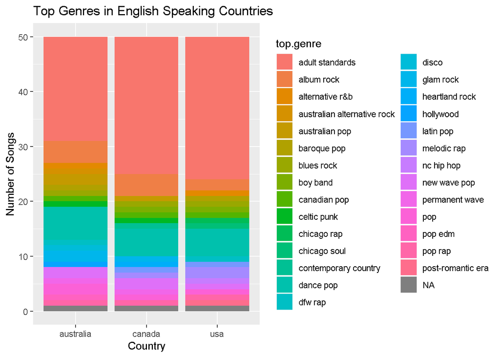

```r
australia <- filter(top50, 150 < X & X < 201)
canada <- filter(top50, 350 < X & X < 401)
usa <- filter(top50, 600 < X & X < 651)

english <- rbind(usa, canada, australia)

group_by(english, country) %>%
  ggplot(aes(x = country, fill = top.genre)) + geom_bar() +
  scale_color_brewer(type = "div", palette = "BrBG") +
  ggtitle("Top Genres in English Speaking Countries") + ylab("Number of Songs") + xlab("Country")
```

Here, we can see that the sample of English speaking countries have very similar tastes in genres around Christmas time, with only small variations based on differences in the location itself, such as the larger volume “australian alternative rock” in Australia.

#### Spanish Genres

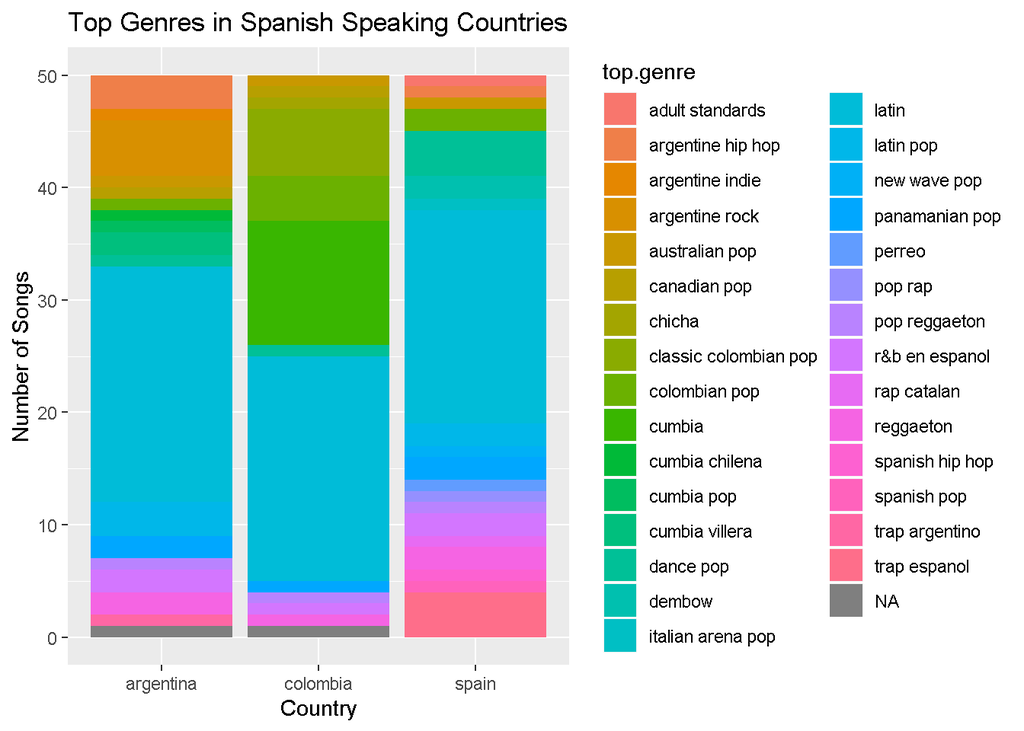

```r
argentina <- filter(top50, 100 < X & X < 151)
columbia <- filter(top50, 450 < X & X < 501)
spain <- filter(top50, 550 < X & X < 601)

spanish <- rbind(argentina, columbia, spain)

group_by(spanish, country) %>%
  ggplot(aes(x = country, fill = top.genre)) + geom_bar() +
  scale_color_brewer(type = "div", palette = "BrBG") +
  ggtitle("Top Genres in Spanish Speaking Countries") + ylab("Number of Songs") + xlab("Country")
```

Like the previous graph with the English speaking countries, the Spanish speaking also follow the same pattern. The most popular genre being Latin, and small variations due to location with the large “columbian pop” concentration in Columbia serving as an example.

#### English Artists

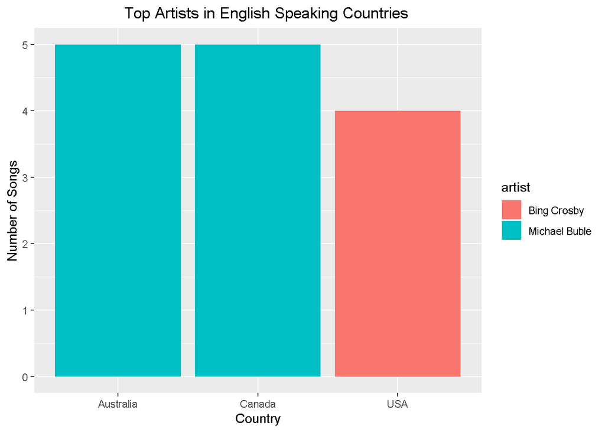

```r
top_aus_artists <- count(australia, artist) %>% arrange(desc(n))
top_aus_artist <- top_aus_artists[c(1:5),]
top_aus_artist$country <- c("Australia")
top_aus_artist$artist <- c("Michael Buble")

top_can_artists <- count(canada, artist) %>% arrange(desc(n))
top_can_artist <- top_can_artists[c(1:5),]
top_can_artist$country <- c("Canada")
top_can_artist$artist <- c("Michael Buble")

top_usa_artists <- count(usa, artist) %>% arrange(desc(n))
top_usa_artist <- top_usa_artists[c(1:4),]
top_usa_artist$country <- c("USA")
top_usa_artist$artist <- c("Bing Crosby")

top_eng_artists <- rbind(top_aus_artist, top_can_artist, top_usa_artist)

group_by(top_eng_artists, country) %>%
  ggplot(aes(x = country, fill = artist)) + geom_bar() +
  scale_color_brewer(type = "div", palette = "BrBG") +
  ggtitle("                    Top Artists in English Speaking Countries") + ylab("Number of Songs") + xlab("Country")
```

#### Spanish Artists

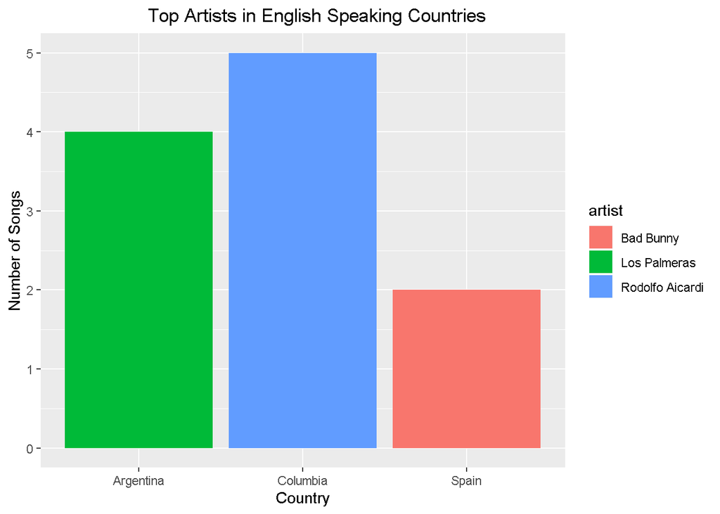

```r
top_arg_artists <- count(argentina, artist) %>% arrange(desc(n))
top_arg_artist <- top_arg_artists[c(1:4),]
top_arg_artist$country <- c("Argentina")
top_arg_artist$artist <- c("Los Palmeras")

top_col_artists <- count(columbia, artist) %>% arrange(desc(n))
top_col_artist <- top_col_artists[c(1:5),]
top_col_artist$country <- c("Columbia")
top_col_artist$artist <- c("Rodolfo Aicardi")

top_spn_artists <- count(spain, artist) %>% arrange(desc(n))
top_spn_artist <- top_spn_artists[c(1:2),]
top_spn_artist$country <- c("Spain")
top_spn_artist$artist <- c("Bad Bunny")

top_spanish_artists <- rbind(top_arg_artist, top_col_artist, top_spn_artist)

group_by(top_spanish_artists, country) %>%
  ggplot(aes(x = country, fill = artist)) + geom_bar() +
  scale_color_brewer(type = "div", palette = "BrBG") +
  ggtitle("                    Top Artists in English Speaking Countries") + ylab("Number of Songs") + xlab("Country")
```

Using the data to generate these plots, the results are not very surprising. The same-language countries almost match each other with their top 50 song genres. There is slight variation in the popular artists between these same-language countries, however this does not provide any real information of interest.